# HLC R Class - Day 2

Brooke Felsheim, Ellen Risemberg, Elena Kharitonova

6/9/2022

# HLC Day 2: Plotting (and factors)

Today we will be covering plotting in R using `ggplot2` and the `factor` data type.

By the end of today’s class, you should be able to:

1. Understand basic `ggplot` syntax
2. Know how `ggplot` views factors and how to relevel them for plotting

## Load data into R

For today’s lecture, we will be using a dataset sourced from the [Gapminder Foundation](https://www.gapminder.org/) that contains data on life expectency, GDP per capita, and population by country. This dataset is available to use in R via a package called `gapminder`.

First, we will want to install the `gapminder` dataset so we can access this data.

```r
install.packages("gapminder")
```

Remember from last week that before a package can be used, it must be loaded to the current R environment with the `library` command. We need to do this once at the beginning of each new R session.

```r
library(gapminder)
```

Loading this package makes a data frame called `gapminder` available in the R environment.

We will also need to load the `ggplot2` package for today’s lesson.

```r
library(ggplot2)
```

For today’s example, we will subset the data to make it simpler to work with. We will cover subsetting data in detail next week, but for now run the following code to generate a data frame tracking life-expectancy, population, & gdp over time in the United States.

```r
# We'll cover dplyr next week!
usa <- dplyr::filter(gapminder, country == "United States")
```

Recall last class’s lesson on ggplot. Do your best to complete the following exercises, referencing previous material or googling a solution as needed.

### Exercise 1

Create a scatterplot of life expectancy (`lifeExp`) over time (`year`) in the code chunk below.

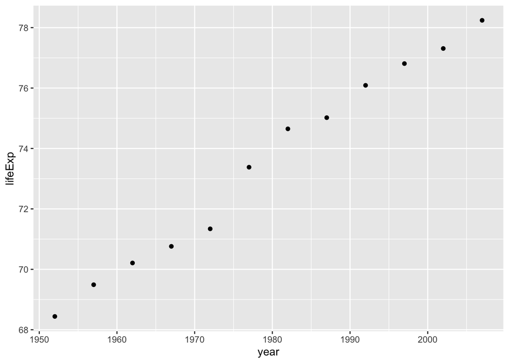

```r
ggplot(data = usa, mapping = aes(x = year, y = lifeExp)) + geom_point()
```

### Exercise 2

Change the point shape to diamonds and increase the point size to 5 in the code chunk below. Hint: Recall that setting parameters not-informed by data is done outside of an `aes()` call.

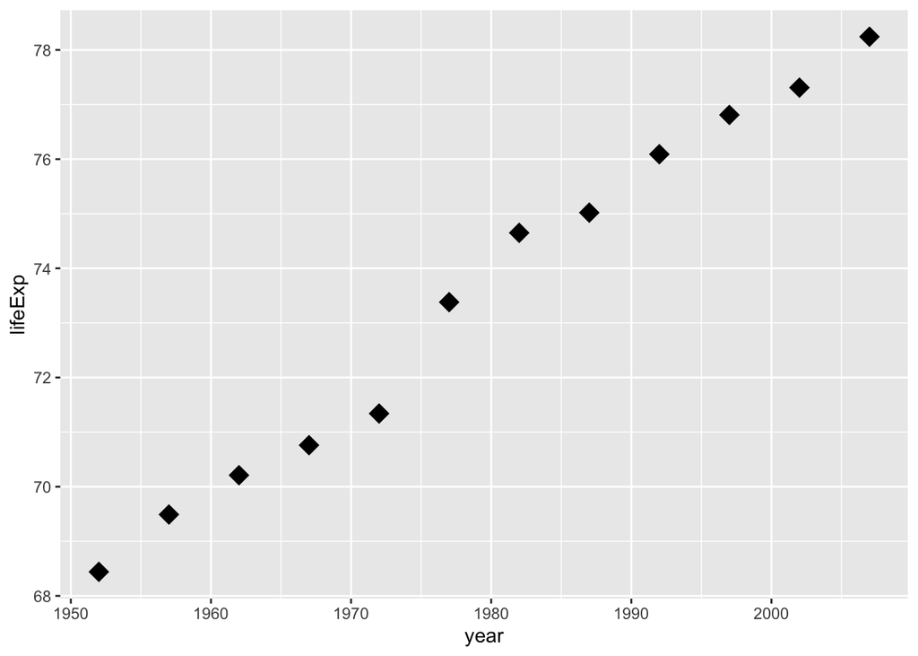

```r
ggplot(data = usa, mapping = aes(x = year, y = lifeExp)) +
  geom_point(shape = 18, size = 5)
```

## Layered grammar of graphics

ggplot adds plot components in layers. The order of addition matters!

Let’s add a line to our scatterplot. Observe that the line is plotted over the points.

We’ve increased the line thickness with the `size` argument so it renders well on a projector.

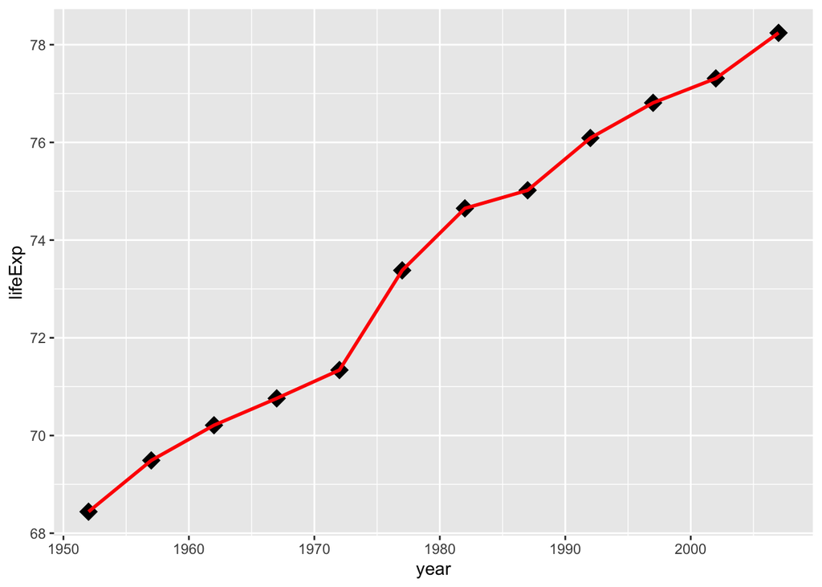

```r
ggplot(data = usa, mapping = aes(x = year, y = lifeExp)) +
  geom_point(shape = 18, size = 5) +
  geom_line(color = "red", size = 1)
```

### Exercise 3

Redo the above plot so that the points are on top of the line in the code chunk below.

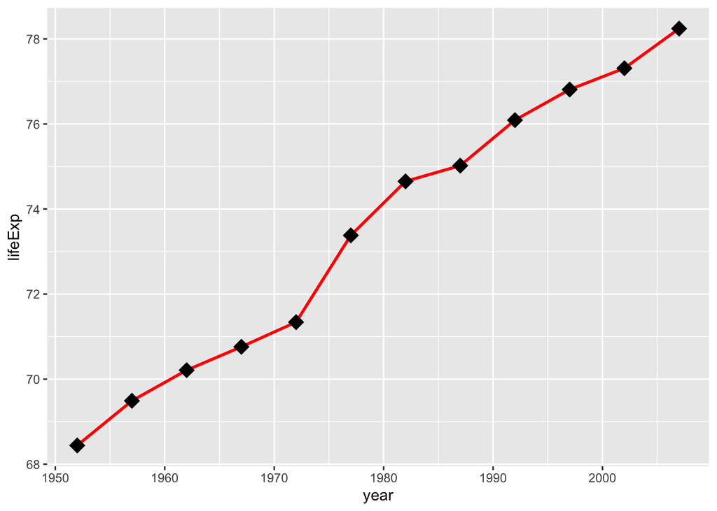

```r
ggplot(data = usa, mapping = aes(x = year, y = lifeExp)) +
  geom_line(color = "red", size = 1) +
  geom_point(shape = 18, size = 5)
```

### Exercise 4

Set the point size to scale with the population (`pop` column) in the code chunk below.

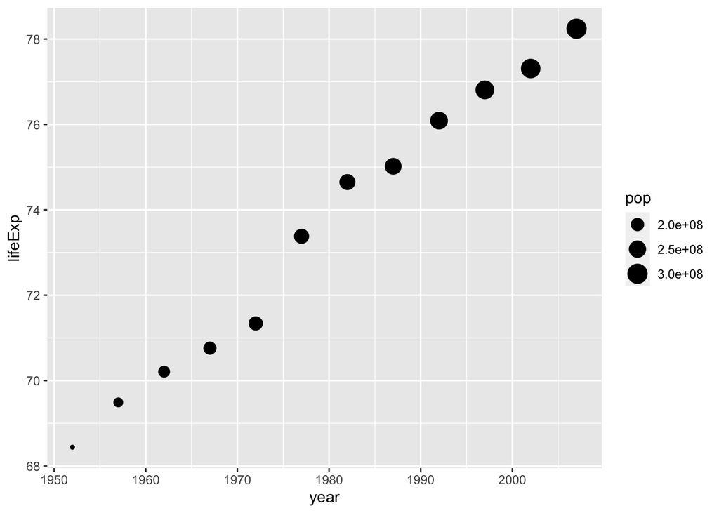

```r
ggplot(data = usa, mapping = aes(x = year, y = lifeExp)) +
  geom_point(aes(size = pop))
```

What happens if you set the color to scale with the population?

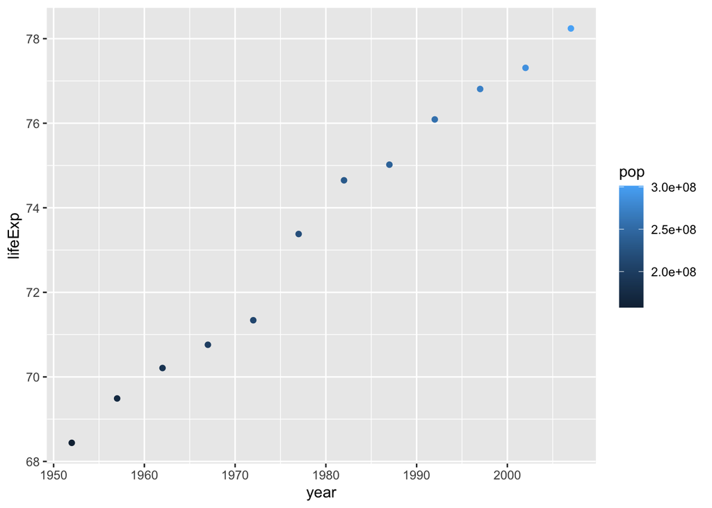

```r
ggplot(data = usa, mapping = aes(x = year, y = lifeExp)) +
  geom_point(mapping = aes(color = pop))
```

What happens if you set the color to distinguish points by continent?

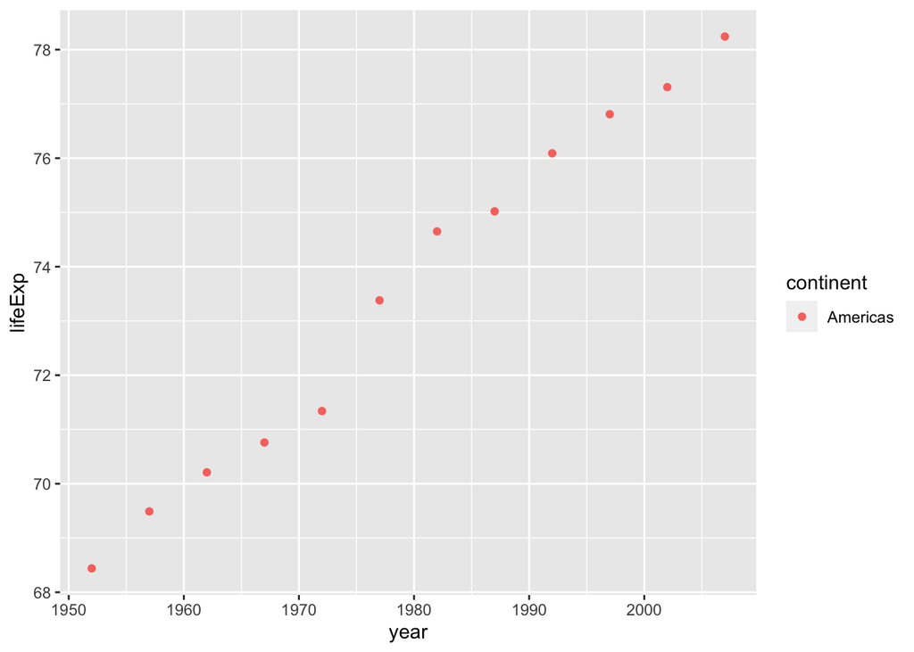

```r
ggplot(data = usa, mapping = aes(x = year, y = lifeExp)) +
  geom_point(aes(color = continent))
```

## The factor data type

Recall the following scatterplot we generated last class that colored points from the iris dataset by Species:

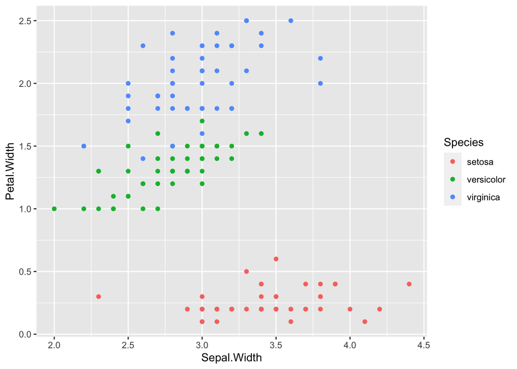

```r
ggplot(iris, aes(Sepal.Width, Petal.Width)) +
  geom_point(aes(color = Species))
```

ggplot interprets categorical variables as `factors` in order to assign their order in the legend, and the color on the plot.

### Factors are *ordered categorical data* with “levels”

By default, the levels are in alphabetical order.

Note how in the below example the ‘levels’ of `myFactors` are arranged alphabetically.

```r
myFactors <- factor(x = c("One", "Two", "Two", "Three"))

myFactors
```

```
## [1] One   Two   Two   Three
## Levels: One Three Two
```

In the iris dataset, the data type of the `Species` column is already a factor:

```r
iris$Species
```

```
##   [1] setosa     setosa     setosa     setosa     setosa     setosa
##   [7] setosa     setosa     setosa     setosa     setosa     setosa
##  [13] setosa     setosa     setosa     setosa     setosa     setosa
##  [19] setosa     setosa     setosa     setosa     setosa     setosa
##  [25] setosa     setosa     setosa     setosa     setosa     setosa
##  [31] setosa     setosa     setosa     setosa     setosa     setosa
##  [37] setosa     setosa     setosa     setosa     setosa     setosa
##  [43] setosa     setosa     setosa     setosa     setosa     setosa
##  [49] setosa     setosa     versicolor versicolor versicolor versicolor
##  [55] versicolor versicolor versicolor versicolor versicolor versicolor
##  [61] versicolor versicolor versicolor versicolor versicolor versicolor
##  [67] versicolor versicolor versicolor versicolor versicolor versicolor
##  [73] versicolor versicolor versicolor versicolor versicolor versicolor
##  [79] versicolor versicolor versicolor versicolor versicolor versicolor
##  [85] versicolor versicolor versicolor versicolor versicolor versicolor
##  [91] versicolor versicolor versicolor versicolor versicolor versicolor
##  [97] versicolor versicolor versicolor versicolor virginica  virginica
## [103] virginica  virginica  virginica  virginica  virginica  virginica
## [109] virginica  virginica  virginica  virginica  virginica  virginica
## [115] virginica  virginica  virginica  virginica  virginica  virginica
## [121] virginica  virginica  virginica  virginica  virginica  virginica
## [127] virginica  virginica  virginica  virginica  virginica  virginica
## [133] virginica  virginica  virginica  virginica  virginica  virginica
## [139] virginica  virginica  virginica  virginica  virginica  virginica
## [145] virginica  virginica  virginica  virginica  virginica  virginica
## Levels: setosa versicolor virginica
```

### Factors can have their order set on assignment

```r
myFactors2 <- factor(c("One", "Two", "Two", "Three"), levels = c("One", "Two", "Three"))

myFactors2
```

```
## [1] One   Two   Two   Three
## Levels: One Two Three
```

### Factors can be also reordered once created

To do this, use the `forcats` library! It’s built for dealing with factors!

```r
library(forcats)
```

All forcats functions start with `fct_`.

`fct_relevel` lets you reorder factors.

Before reordering:

```r
myFactors
```

```
## [1] One   Two   Two   Three
## Levels: One Three Two
```

After reordering:

```r
fct_relevel(myFactors, c("One", "Two", "Three"))
```

```
## [1] One   Two   Two   Three
## Levels: One Two Three
```

`fct_rev` reverses the order of levels.

Before reversing:

```r
myFactors2
```

```
## [1] One   Two   Two   Three
## Levels: One Two Three
```

After reversing:

```r
fct_rev(myFactors2)
```

```
## [1] One   Two   Two   Three
## Levels: Three Two One
```

## ggplot customization with factors

Again, recall the colored scatterplot we generated earlier:

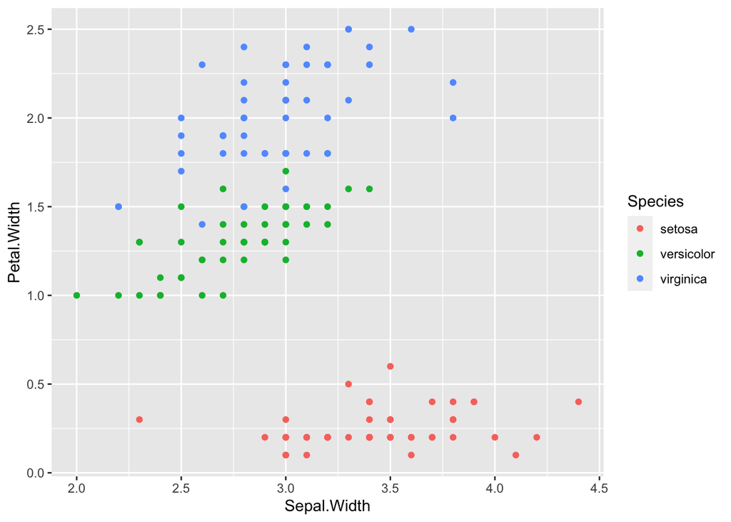

```r
ggplot(iris, aes(Sepal.Width, Petal.Width)) +
  geom_point(aes(color = Species))
```

The order of the factors in the legend (and thus the default color assignment) can be changed by reordering the factor levels!

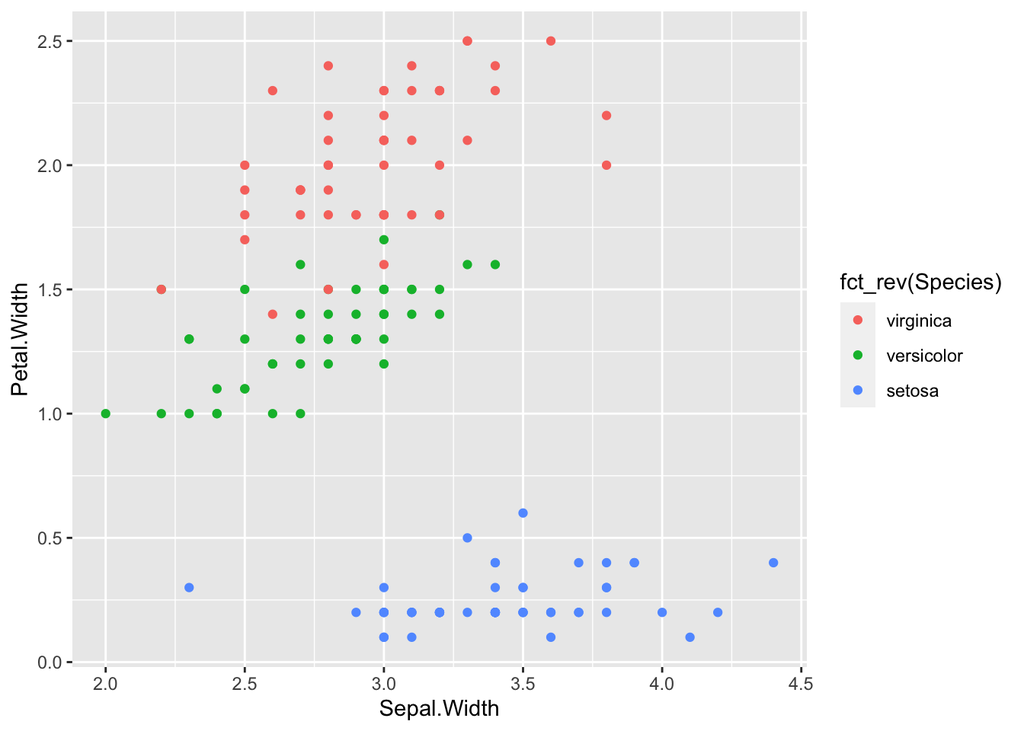

```r
ggplot(iris, aes(Sepal.Width, Petal.Width)) +
  geom_point(aes(color = fct_rev(Species)))
```

## Setting ggplot axis labels and title

For these examples we will again use the data from the `gapfinder` package. This time, we will use the full dataset containing data for 142 countries.

Recall that we can save ggplots as a variable in R. Let’s generate a scatterplot of life expectancy by year for all countries and save it to the variable `myPlot`.

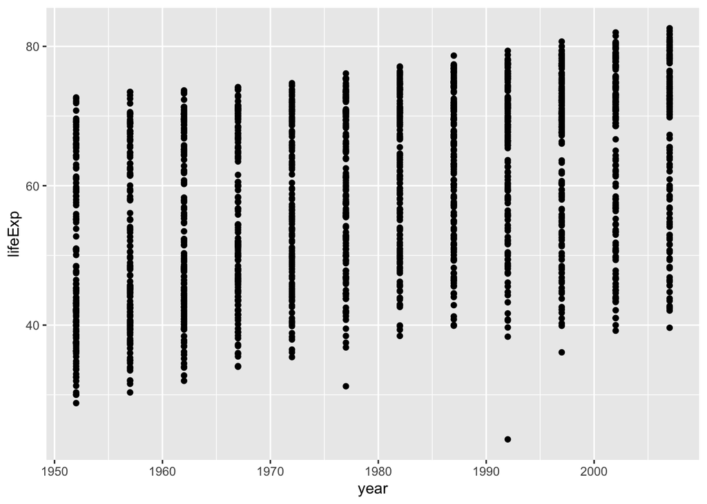

```r
myPlot <- ggplot(data = gapminder, mapping = aes(x = year, y = lifeExp)) +
    geom_point()

myPlot
```

We can still make modifications to a ggplot that has been saved to a variable! We will modify the `myPlot` variable in the steps below.

Titles can be added with `ggtitle()`:

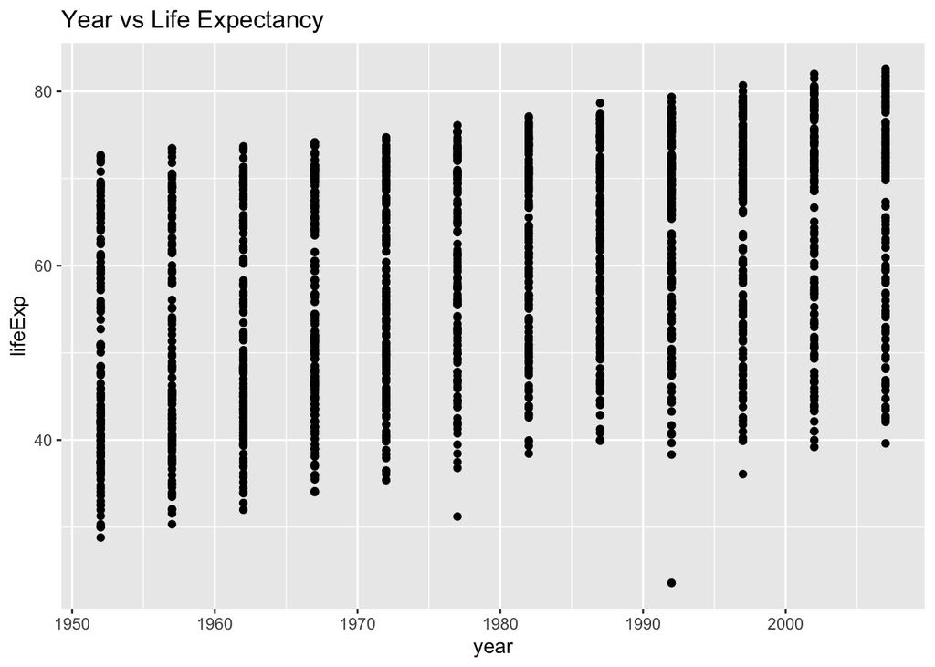

```r
myPlot +
  ggtitle("Year vs Life Expectancy")
```

Axis labels can be customized with `xlab()` and `ylab()`:

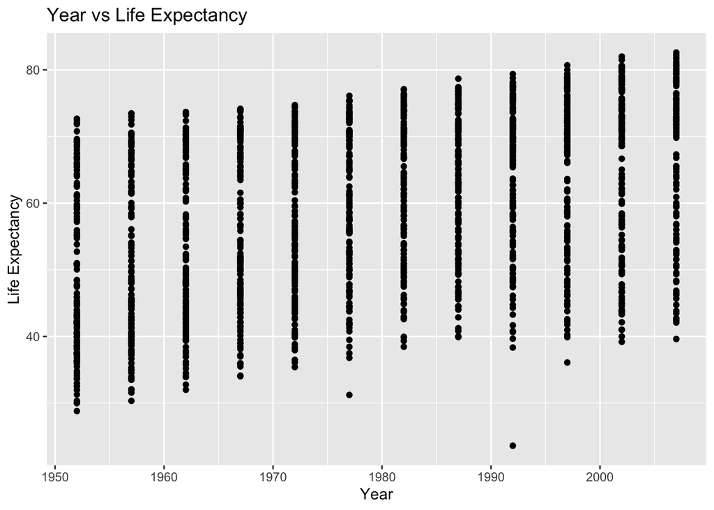

```r
myPlot +
  ggtitle("Year vs Life Expectancy") +
  xlab("Year") +
  ylab("Life Expectancy")
```

Global aesthetics can be added to the whole plot:

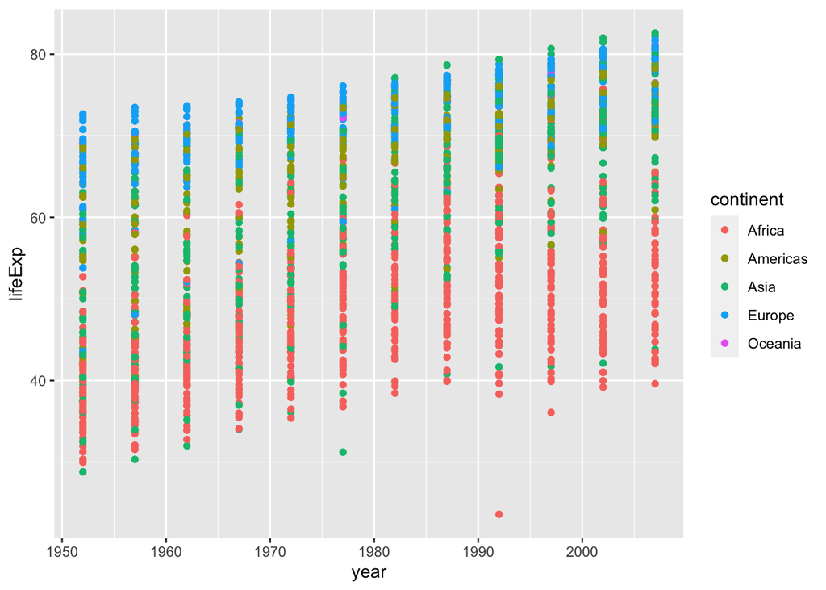

```r
myPlot +
  aes(color = continent)
```